# world-cafe study (informing basal attributes, S2)

Author

Julius Fenn, Louisa Estadieu

# Notes

# prepare data

## set up data.frame

```r
########################################
# create counter variable for data set
########################################
dat$ID <- NA

tmp_IDcounter <- 0
for(i in 1:nrow(dat)){
  if(!is.na(dat$sender[i]) && dat$sender[i] == "Greetings"){
    # tmp <- dat$prolific_pid[i]
    tmp_IDcounter = tmp_IDcounter + 1
  }
  dat$ID[i] <- tmp_IDcounter
}


########################################
# keep only complete data sets
########################################
sum(table(dat$ID) != max(table(dat$ID)))
```

```
[1] 15
```

```r
sum(table(dat$ID) == max(table(dat$ID)))
```

```
[1] 21
```

```r
dat <- dat[dat$ID %in% names(table(dat$ID))[table(dat$ID) == max(table(dat$ID))],]

########################################
# json (from JATOS) to 2D data.frame
########################################
tmp_notNumeric <- str_subset(string = colnames(dat), pattern = "^meta")
tmp_notNumeric <- str_subset(string = tmp_notNumeric, pattern = "labjs|location", negate = TRUE)

# tmp_numeric <- str_subset(string = colnames(dat), pattern = "^affImgAffect|^CRKQ|^CCSQ|^CMQ|^GCB")


vec_ques <- c("dummy_informedconsent",
              tmp_notNumeric,

              "applicationsSR", "applicationsSRdefinition",

              "benefitsSR", "benefitsSRdefinition",
              "risksSR", "risksSRdefinition",

              "socialBenefitsSR", "socialBenefitsSRdefinition",
              "socialRisksSR", "socialRisksSRdefinition",

              "sustainableSR", "sustainableSRdefinition",

              "feedback_critic")

vec_notNumeric = c("dummy_informedconsent",
              tmp_notNumeric,

              "applicationsSR", "applicationsSRdefinition",

              "benefitsSR", "benefitsSRdefinition",
              "risksSR", "risksSRdefinition",

              "socialBenefitsSR", "socialBenefitsSRdefinition",
              "socialRisksSR", "socialRisksSRdefinition",

              "sustainableSR", "sustainableSRdefinition",

              "feedback_critic")

questionnaire <- questionnairetype(dataset = dat,
                                        listvars = vec_ques,
                                        notNumeric = vec_notNumeric)
```

## get reaction times for single components

*not needed*

## clean data (if needed)

*not needed*

# describe data

## sample description

```r
## number of participants
nrow(questionnaire)
```

```
[1] 21
```

# open questions

## applications of soft robots

**open question:** What are the most promising applications of soft robots over their rigid counterparts within your field of expertise?

```r
DT::datatable(questionnaire[, c("applicationsSR","applicationsSRdefinition")], options = list(pageLength = 5))
```

|  | applicationsSR | applicationsSRdefinition |
| --- | --- | --- |
| 1 | 1 | Can survive damage, might be able to reach places/be used at places, where softness is a big advantage. |
| 2 | 0 |  |
| 3 | 1 | sensitive objects (medical) , harsh environments (marine) |
| 4 | 0 |  |
| 5 | 1 | They can be more adaptive, shape-change, and responsive. |
| 6 | 0 |  |
| 7 | 1 | Human machine Interaction Fitting through tight spaces |
| 8 | 1 | large elastic deformation of the robot: in tight spaces, interaction with fragile objects |
| 9 | 1 | medical applications |
| 10 | 1 | adaptivity to new surrounding |

[output cut: 11 more lines]

## main benefits and risks of soft robots

**open questions:**

- In your expert opinion, what are the main benefits of soft robots compared to rigid robots?
- In your expert opinion, what are the main risks of soft robots compared to rigid robots?

```r
DT::datatable(questionnaire[, c("benefitsSR","benefitsSRdefinition",
                                "risksSR","risksSRdefinition")], options = list(pageLength = 5))
```

|  | benefitsSR | benefitsSRdefinition | risksSR | risksSRdefinition |
| --- | --- | --- | --- | --- |
| 1 | 1 | Interaction of soft robots with humans might be safer due to usage of less stiff material. | 0 |  |
| 2 | 1 | Replacing real parts | 0 |  |
| 3 | 1 | different, additional fields of applications. Long-lasting | 0 |  |
| 4 | 1 | can adapt to different situations/conditions can handle physical damage better | 0 |  |
| 5 | 1 | dtto | 0 |  |
| 6 | 1 | More sutainable More interesting | 0 |  |
| 7 | 1 | Less likely to hurt people Fitting through tight spaces | 0 |  |
| 8 | 1 | less risk for injury when interacting with the living world | 1 | slow response, limited functionality |
| 9 | 1 | have more functions, more energy efficient | 1 | not as robust, potential 'evil' use |
| 10 | 1 | The robots can be applied in new, unknown or very harsh conditions | 0 |  |

[output cut: 11 more lines]

## social benefits and risks of soft robots

**open questions:**

- From your expert perspective, what do you identify as the primary social benefits of soft robots compared to rigid robots?
- From your expert perspective, what do you identify as the primary social risks of soft robots compared to rigid robots?

```r
DT::datatable(questionnaire[, c("socialBenefitsSR","socialBenefitsSRdefinition",
                                "socialRisksSR","socialRisksSRdefinition")], options = list(pageLength = 5))
```

|  | socialBenefitsSR | socialBenefitsSRdefinition | socialRisksSR | socialRisksSRdefinition |
| --- | --- | --- | --- | --- |
| 1 | 1 | More flexible structure could give them a more naturalm shape. | 0 |  |
| 2 | 0 |  | 0 |  |
| 3 | 1 | energy-and resource saving | 0 |  |
| 4 | 0 |  | 0 |  |
| 5 | 1 | Less dangerous for people. | 0 |  |
| 6 | 0 |  | 0 |  |
| 7 | 0 |  | 0 |  |
| 8 | 0 |  | 0 |  |
| 9 | 1 | More interaction with humans | 1 | More interaction with humans:) |
| 10 | 0 |  | 0 |  |

[output cut: 11 more lines]

## environmental impacts of soft robots

**open question:** From your expert point of view, could you elaborate on the potential environmental impacts of soft robots, considering aspects like energy efficiency, and end-of-life disposal, particularly in comparison to rigid robots?

```r
DT::datatable(questionnaire[, c("sustainableSR","sustainableSRdefinition")], options = list(pageLength = 5))
```

|  | sustainableSR | sustainableSRdefinition |
| --- | --- | --- |
| 1 | 1 | More light-weight material could lower energy consumption during life span. |
| 2 | 1 | Its soft therefore, life-like. |
| 3 | 1 | at the moment soft robots consist of many different elements, which needs to be manufactured in complex processes. This is also problematic for recycling. |
| 4 | 1 | can handly physical damag better -&gt; longer lasting |
| 5 | 0 |  |
| 6 | 1 | Less use of electrical parts with low working lifetime Cost of the manufacturing of the soft robot is significant lower than the manufacturing of the rigid robots |
| 7 | 0 |  |
| 8 | 0 |  |
| 9 | 1 | reusability and thus sutainability are a big advantage, at least I believe so. |
| 10 | 0 |  |

[output cut: 11 more lines]

### save as Excel

as .xlsx file

```r
tmp_dat <- questionnaire[, c("ID",
"applicationsSR","applicationsSRdefinition",
"benefitsSR","benefitsSRdefinition",
"risksSR","risksSRdefinition",
"socialBenefitsSR","socialBenefitsSRdefinition",
"socialRisksSR","socialRisksSRdefinition",
"sustainableSR","sustainableSRdefinition",
"feedback_critic")]
xlsx::write.xlsx2(x = tmp_dat, file = "outputs/openQuestions.xlsx")
```

## general feedback, critic

```r
tmp_dat <- questionnaire[questionnaire$feedback_critic != "" & !is.na(questionnaire$feedback_critic), c("ID","feedback_critic")]
DT::datatable(tmp_dat, options = list(pageLength = 5))
```

|  | ID | feedback_critic |
| --- | --- | --- |
| 2 | 3 | Some questions were repeating |
| 3 | 4 | no |
| 4 | 5 | Sometimes I found it difficult to answer some questions. That could be because the questions werenot self-explainatory enough, or I'm just not used to these type of studies/questions and therefore str… |
| 6 | 8 | First set of questions were a bit abstract, is hard to emotionally relate to words |
| 8 | 10 | selection of additional words per area is a bit clumsy and not self expaining. |
| 14 | 27 | The questions are partly inflexible, i.e. too black and white. E.g. sustainability of soft versus conventional robots depends very much on the materials they are build of. It is therefore not a yes/no… |
| 16 | 30 | Maybe it would be helpful to at least give some broad definition of the adjectives and a context. Many different disciplines have different definitions of terms such as "autonomy" and that is probably… |
| 19 | 33 | could have added a third option like maybe with yes or no questions. |

# basal attributes

## relevancy and valence ratings

error: two times I surved “autonomous” (German: selbstständig, autonom)

```r
########################################
# get data set with all ratings
########################################
dat_ratings <- na.omit(dat[, c("ID", "Attribut", "English_translation", "ratingLivmats", "ratingValence")])
dat_ratings$ratingLivmats <- as.numeric(dat_ratings$ratingLivmats)
dat_ratings$ratingValence <- as.numeric(dat_ratings$ratingValence)

if(nrow(dat_ratings) / 32 == nrow(questionnaire)){
  print("Everything worked fine")
}
```

```
[1] "Everything worked fine"
```

```r
########################################
# summary of all ratings
########################################
summary_ratings <- dat_ratings %>%
  group_by(English_translation) %>%
  summarize(N = n(),
            mean_ratingLivmats = mean(ratingLivmats), SD_ratingLivmats = sd(ratingLivmats),
            mean_ratingValence = mean(ratingValence), SD_ratingValence = sd(ratingValence)) %>%
  mutate(across(3:6, round, 2))
DT::datatable(summary_ratings, options = list(pageLength = 5))
```

|  | English_translation | N | mean_ratingLivmats | SD_ratingLivmats | mean_ratingValence | SD_ratingValence |
| --- | --- | --- | --- | --- | --- | --- |
| 1 | adaptive | 21 | 8.57 | 1.25 | 5.67 | 1.11 |
| 2 | anisotropic | 21 | 5.05 | 1.69 | 4.19 | 0.6 |
| 3 | autonomous | 42 | 7.62 | 1.86 | 4.95 | 1.1 |
| 4 | bio-inspired | 21 | 7.76 | 1.76 | 5.43 | 1.16 |
| 5 | biologically inspired | 21 | 7.67 | 1.83 | 5.19 | 1.25 |
| 6 | changeable | 21 | 6.67 | 1.96 | 4.43 | 1.08 |
| 7 | changeable shape | 21 | 6.81 | 1.97 | 4.57 | 0.98 |
| 8 | durable | 21 | 8.14 | 1.42 | 5.67 | 0.97 |
| 9 | ecologically | 21 | 7.48 | 1.94 | 5.48 | 1.36 |
| 10 | electronic-free | 21 | 6.52 | 2.2 | 4.48 | 0.98 |

[output cut: 21 more lines]

```r
## save
xlsx::write.xlsx2(x = summary_ratings, file = "outputs/summary_ratings.xlsx")

########################################
# get words of basal attributes => 6
########################################
summary_ratings$English_translation[summary_ratings$mean_ratingLivmats >= 6]
```

```
 [1] "adaptive"                 "autonomous"
 [3] "bio-inspired"             "biologically inspired"
 [5] "changeable"               "changeable shape"
 [7] "durable"                  "ecologically"
 [9] "electronic-free"          "energy autonomous"
[11] "energy-efficient"         "environmentally friendly"
[13] "intelligent"              "life-like"
[15] "maintenance-free"         "multifunctional"
[17] "reactive"                 "reliable"
[19] "resilient"                "responsive"
[21] "robust"                   "self-healing"
[23] "self-repairing"           "storing energy"
[25] "sustainable"              "technological"
[27] "versatile"
```

Plot relevancy ratings:

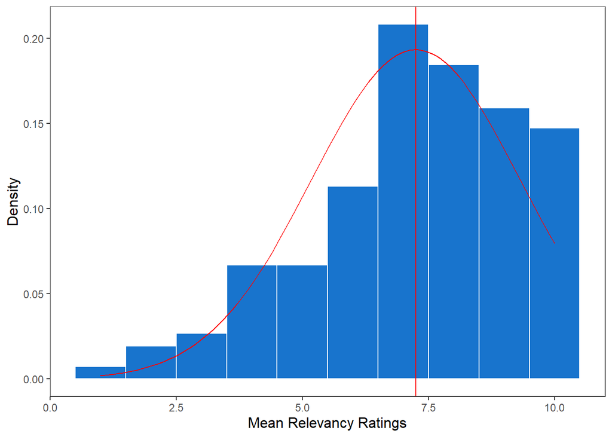

```r
# Calculate mean and standard deviation
mu <- mean(dat_ratings$ratingLivmats, na.rm = TRUE)
sigma <- sd(dat_ratings$ratingLivmats, na.rm = TRUE)

# Create the histogram with normal distribution overlay
ggplot(dat_ratings, aes(x = ratingLivmats)) +
  geom_histogram(aes(y = ..density..), binwidth = 1, fill = "dodgerblue3", color = "white") +
  stat_function(fun = dnorm, args = list(mean = mu, sd = sigma), color = "red") +
  labs(x = "Mean Relevancy Ratings", y = "Density") +
  theme_apa() +
  theme(plot.title = element_text(hjust = 0.5)) + geom_vline(xintercept = mean(dat_ratings$ratingLivmats, na.rm = TRUE), col = "red")
```

Plot valence ratings:

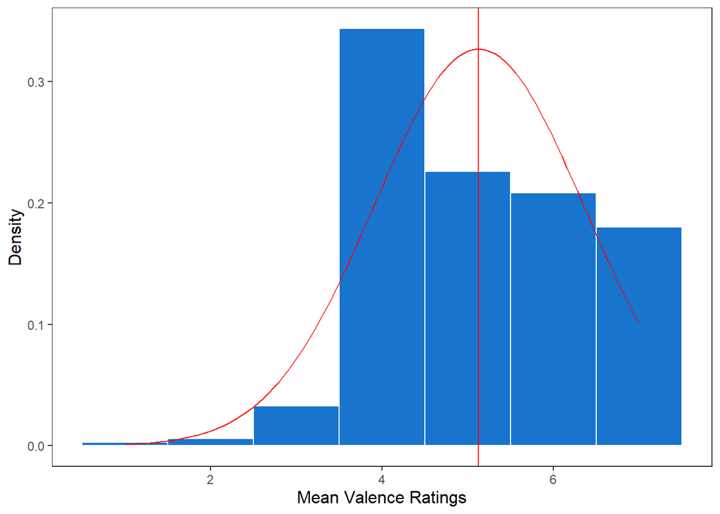

```r
# Calculate mean and standard deviation
mu <- mean(dat_ratings$ratingValence, na.rm = TRUE)
sigma <- sd(dat_ratings$ratingValence, na.rm = TRUE)

# Create the histogram with normal distribution overlay
ggplot(dat_ratings, aes(x = ratingValence)) +
  geom_histogram(aes(y = ..density..), binwidth = 1, fill = "dodgerblue3", color = "white") +
  stat_function(fun = dnorm, args = list(mean = mu, sd = sigma), color = "red") +
  labs(x = "Mean Valence Ratings", y = "Density") +
  theme_apa() +
  theme(plot.title = element_text(hjust = 0.5)) + geom_vline(xintercept = mean(dat_ratings$ratingValence, na.rm = TRUE), col = "red")
```

**both are medium-strongly slightly related**

```r
cor(dat_ratings$ratingLivmats, dat_ratings$ratingValence)
```

```
[1] 0.4447086
```

## missing basal attributes for single research areas

for **Research Area A (Energy Autonomy):**

```r
table(unlist(dat$toolsStatistics))
```

```
     adaptivty convert energy Energy storage harvest energy          local
             1              3              5              7              3
     renewable
             1
```

for **Research Area B (Adaptivity):**

```r
table(unlist(dat$toolsSoftwares))
```

```
         adaptivty       feasability              health           learning
                 6                  1                  1                  3
          lifetime           training trigger responsive
                 1                  2                  5
```

for **Research Area C (Longevity):**

```r
table(unlist(dat$toolsTopics))
```

```
        adaptivty          circular          lifetime      long-lasting
                1                 4                 3                 5
        permanent         recycling        Redundancy      self-healing
                1                 3                 2                 3
     self-sealing       Sustainable Trained materials
                2                 4                 2
```

for **Research Area D (Societal challenges and Sustainability):**

```r
table(unlist(dat$toolsData))
```

```
 accaptance in society              adaptivty                 agency
                     5                      1                      1
    change in society     critical evaluation individual vs. society
                     1                      1                      4
   local vs. worldwide               politics         sustainability
                     2                      3                      2
```